# Homework 3

## Part 1: Optimization (5 points)

Optimization underlies the determination of parameter settings based on minimization of an objective. We derived this for maximum likelihood of linear regression and showed a regularized version. In this exercise, we will use gradient descent to learn the parameters for logistic regression. Then we will impose a regularizer to keep the parameters closer to 0 in attempts to reduce variance.

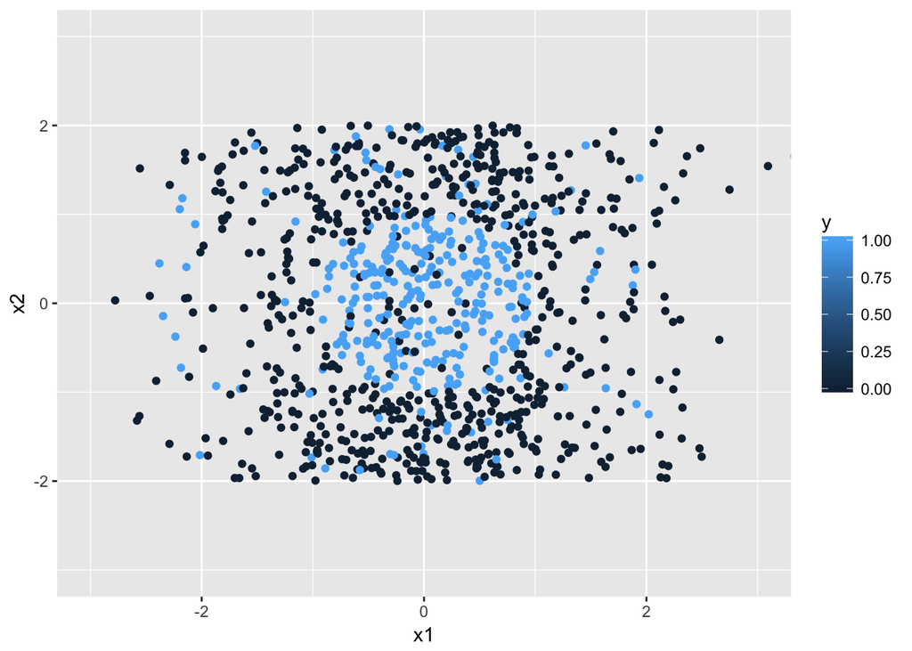

```r
require(dplyr)
# Generate some data - do not change
set.seed(12345)
data.size = 1000
get_data = function(n=data.size) {
  df = data.frame(x1 = rnorm(n),x2=4*runif(n)-2) %>%
    tbl_df() %>%
    mutate(y = (x1^2+x2^2)<1) %>%
    mutate(y = (function(.) {.[runif(data.size)<0.1] = 0; .})(y)) %>%
    mutate(y = (function(.) {.[runif(data.size)<0.1] = 1; .})(y))
  df
}

df = get_data(data.size)

require(ggplot2)
ggplot(data = df, aes(x=x1,y=x2,color=y)) + geom_point() + coord_cartesian(xlim=c(-3,3), ylim=c(-3,3))
```

1. Perform logistic regression using glm or other package

```r
lr <- glm(formula = y  ~ .,
          family=binomial(link="logit"),data = df, control = list(maxit = 100))
```

2. Perform logistic regression using optim. Compare your parameters from optim to the glm parameters.

```r
linear_prediction = function(x1,x2, pars) {
  pars[1]+ pars[2]*x1 + pars[3]*x2
}
sq_loss = function(pars, y, x1,x2) {
  sum((y-linear_prediction(x1,x2,pars))^2) #toefte
}
opt <- optim(par=rep(0,3), fn=sq_loss, y=df$y, x1=df$x1, x2=df$x2)
opt$par
```

```
## [1]  0.31905189 -0.01091319  0.01608027
```

```r
lr$coefficients
```

```
## (Intercept)          x1          x2
## -0.75996355 -0.05045337  0.07429184
```

```r
print("to compare the intercept:")
```

```
## [1] "to compare the intercept:"
```

```r
log(opt$par[1]/(1-opt$par[1]))
```

```
## [1] -0.7581323
```

3. Perform logistic regression with L2 regularization

```r
sq_loss_l2_regularized = function(pars, y, x1, x2, lambda=100) {
  sq_loss(pars,y,x1,x2) + lambda*sum(pars[2]^2+pars[3]^2) # omit the intercept
}
optreg = optim(par=rep(0,3), sq_loss_l2_regularized, y=df$y, x1=df$x1, x2=df$x2)
optreg$par
```

```
## [1]  0.318944584 -0.009935845  0.015000441
```

4. Perform logistic regression using optim with quadratic terms

```r
linear_prediction = function(x1,x2, pars) {
  pars[1]+ pars[2]*x1 + pars[3]*x2
}
quadratic_term_prediction1 = function(x1,x2, pars) {
  (x1*pars[2] + x2*pars[3] + pars[1])^2
}
quadratic_term_prediction2 = function(x1,x2, pars) {
   pars[1] + x1* pars[2] + x2 * pars[3] + x1^2*pars[4] + x2^2 * pars[5] + x1*x2*pars[6]
}
sq_loss_quadratic = function(pars, y, x1, x2) {
  sum((y-quadratic_term_prediction2(x1,x2,pars))^2)
}
optquad <- optim(par=rep(0,6), fn=sq_loss_quadratic, y=df$y, x1=df$x1, x2=df$x2)
optquad$par
```

```
## [1]  0.619655201 -0.002794834  0.009348874 -0.069353498 -0.170366266
## [6]  0.005311921
```

5. Perform logistic regression with L2 regularization with quadratic terms

```r
sq_loss_l2_regularized_quadratic = function(pars, y, x1, x2, lambda=100) {
  sq_loss_quadratic(pars,y,x1,x2) + lambda*sum(pars[2]^2+pars[3]^2)
}
optquadreg <- optim(par=rep(0,6), fn=sq_loss_l2_regularized_quadratic, y=df$y, x1=df$x1, x2=df$x2)
optquadreg$par
```

```
## [1]  0.619682832 -0.002475944  0.008431963 -0.069336099 -0.170405460
## [6]  0.005312495
```

6. Create a learning curve for parts b, c, d, e. Interpret your learning curve.

```r
accuracies = data.frame(x = numeric(100), opt = numeric(100), optreg=numeric(100), optquad=numeric(100),optquadreg=numeric(100))
test = df[seq(nrow(df)/2,nrow(df),1),]
for (i in 1:100 ){
  optaccuracy = 0
  optregaccuracy = 0
  optquadaccuracy = 0
  optquadregaccuracy = 0
  train = df[seq(1,nrow(df)/2/100*i,1),]
  opt = optim(par=rep(0,3), fn=sq_loss, y=train$y, x1=train$x1, x2=train$x2)
  optreg = optim(par=rep(0,3), fn=sq_loss_l2_regularized, y=train$y, x1=train$x1, x2=train$x2)
  optquad = optim(par=rep(1,6), fn=sq_loss_quadratic, y=train$y, x1=train$x1, x2=train$x2)
  optquadreg = optim(par=rep(1,6), fn=sq_loss_l2_regularized_quadratic, y=train$y, x1=train$x1, x2=train$x2)
  for (c in 1:nrow(test)) {
    if((opt$par[1] + opt$par[2]*test$x1[c] + opt$par[3]*test$x2[c] >  mean(test$y)) == (test$y[c]==1 )) {
      optaccuracy = optaccuracy + 1
    }

    if((optreg$par[1] + optreg$par[2]*test$x1[c] + optreg$par[3]*test$x2[c] >  mean(test$y)) == (test$y[c]==1 )) {
      optregaccuracy = optregaccuracy + 1
    }
    if((optquadreg$par[1] + optquadreg$par[2]*test$x1[c] + optquadreg$par[3]*test$x2[c] + optquadreg$par[4]*test$x1[c]^2
          + optquadreg$par[5]*test$x2[c]^2 + optquadreg$par[6]*test$x2[c]*test$x1[c] >   mean(test$y)) == (test$y[c]==1 )) {
      optquadaccuracy = optquadaccuracy + 1
    }
    if((optquadreg$par[1] + optquadreg$par[2]*test$x1[c] + optquadreg$par[3]*test$x2[c] + optquadreg$par[4]*test$x1[c]^2
          + optquadreg$par[5]*test$x2[c]^2 + optquadreg$par[6]*test$x2[c]*test$x1[c] >   mean(test$y)) == (test$y[c]==1 )) {
      optquadregaccuracy = optquadregaccuracy + 1
    }
    accuracies$x[i] <- i
    accuracies$opt[i] <- optaccuracy/nrow(test)
    accuracies$optreg[i] <- optregaccuracy/nrow(test)
    accuracies$optquad[i] <- optquadaccuracy/nrow(test)
    accuracies$optquadreg[i] <- optquadregaccuracy/nrow(test)
  }
}

accuracies
```

```
##       x       opt    optreg   optquad optquadreg
## 1     1 0.3852295 0.3133733 0.5229541  0.5229541
## 2     2 0.4950100 0.3133733 0.4690619  0.4690619
## 3     3 0.4291417 0.3133733 0.6487026  0.6487026
## 4     4 0.4391218 0.3133733 0.6207585  0.6207585
## 5     5 0.4710579 0.3552894 0.5768463  0.5768463
## 6     6 0.4790419 0.4610778 0.6147705  0.6147705
## 7     7 0.4610778 0.4590818 0.6227545  0.6227545
## 8     8 0.4510978 0.4411178 0.6047904  0.6047904
## 9     9 0.4730539 0.5828343 0.4491018  0.4491018
## 10   10 0.6207585 0.6866267 0.6147705  0.6147705
## 11   11 0.5009980 0.5029940 0.6027944  0.6027944
## 12   12 0.4770459 0.4750499 0.4491018  0.4491018
## 13   13 0.4870259 0.4890220 0.6107784  0.6107784
## 14   14 0.4910180 0.5748503 0.5289421  0.5289421
```

[output cut: 86 more lines]

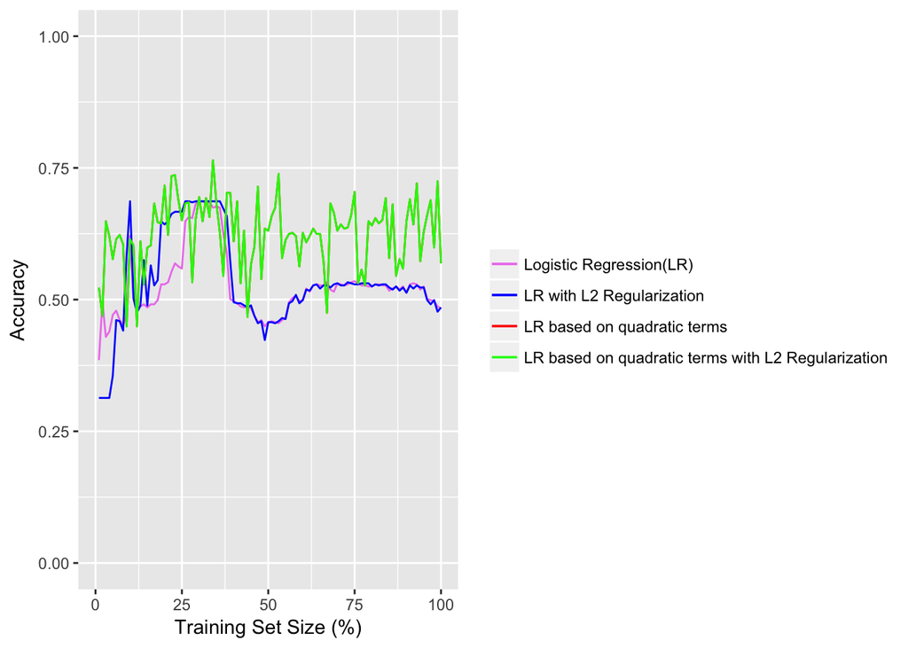

```r
ggplot(data = accuracies, aes(x)) + ylab("Accuracy") + xlab("Training Set Size (%)")  + geom_line(aes(y = opt, color="Logistic Regression(LR)")) + geom_line(aes(y = optreg, color="LR with L2 Regularization")) + geom_line(aes(y = optquad,color="LR based on quadratic terms")) + geom_line(aes(y = optquadreg,color="LR based on quadratic terms with L2 Regularization")) + coord_cartesian(xlim=c(0,100), ylim=c(0,1)) + scale_colour_manual("", breaks = c("Logistic Regression(LR)", "LR with L2 Regularization", "LR based on quadratic terms", "LR based on quadratic terms with L2 Regularization"), values = c("red", "green", "blue","violet"))
```